# Chapter 5 GLM

```r
knitr::opts_chunk$set(warning = FALSE, message = FALSE)
# Libraries
library(tidyverse)
library(cmdstanr)
library(posterior)
library(bayesplot)
library(GGally)
library(pROC)
color_scheme_set('purple')


# Define the Night Owl theme
night_owl_theme <- theme(
  # Overall plot appearance
  plot.background = element_rect(fill = "#011627"),  # Dark blue background
  plot.title = element_text(color = "#FFD166", size = 18, hjust = 0.5),  # Light yellow title
  plot.subtitle = element_text(color = "#FFD166", size = 14, hjust = 0.5),  # Light yellow subtitle

  # Axis appearance
  axis.line = element_line(color = "white"),  # White axis lines
  axis.text = element_text(color = "white"),  # White axis text
  axis.title = element_text(color = "white"),  # White axis titles
  axis.ticks = element_line(color = "white"),  # White axis tick marks

  # Panel appearance
  panel.background = element_rect(fill = "#011627"),  # Dark blue panel background
  panel.grid.major = element_line(color = "#303B50"),  # Gray grid lines
  panel.grid.minor = element_line(color = "#192138"),  # Dark gray grid lines

  # Legend appearance
  legend.background = element_rect(fill = "#011627"),  # Dark blue legend background
  legend.title = element_text(color = "white"),  # White legend title
  legend.text = element_text(color = "white"),  # White legend text

  # Facet appearance
  strip.background = element_rect(fill = "#011627"),  # Dark blue facet strip background
  strip.text = element_text(color = "white")  # White facet strip text
)
```

## Purpose

Working through chapter 5: basic regressions and model checking.

### 5.1 Multiple Linear Regression

```r
data_5.1 <- read.csv('./data/data-shopping-1.csv')

head(data_5.1)
```

```
  PersonID Sex Income    Y
1        1   0   85.1 0.56
2        2   1   64.6 0.59
3        3   0   97.6 0.56
4        4   1   72.8 0.65
5        5   1   51.1 0.55
6        6   0   86.9 0.55
```

Pairs plot of variable relationships.

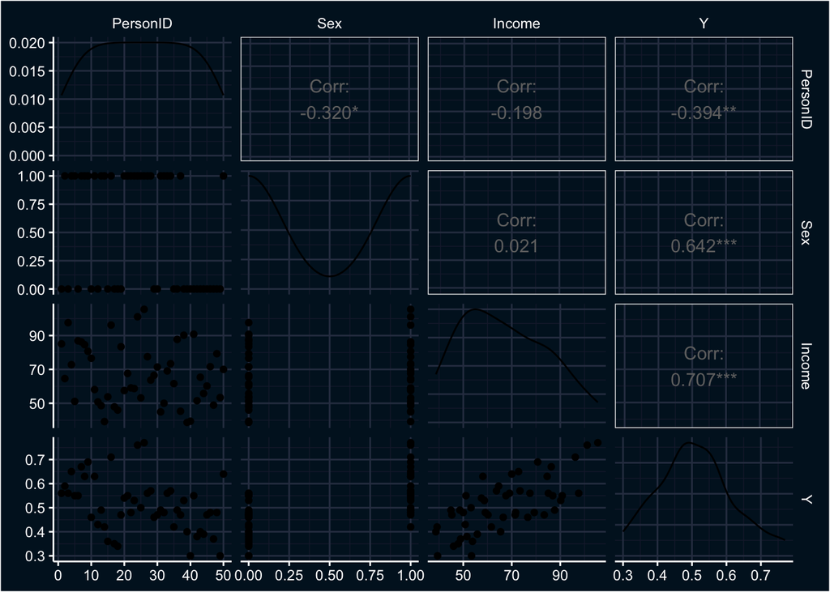

```r
ggpairs(data_5.1) +
  night_owl_theme
```

$$\mu[n] = \alpha + \beta_1*Sex[n] + \beta_2 * Income[n] + \epsilon[n] \\
Y[n] \backsim N(\mu[n], \sigma)$$
{#eq-5.1 - multivariable}

Will also include a simulation to see if we can recover parameters.

```r
# Divide income by 100
data_5.1$Income <- data_5.1$Income/100
# data as a list
d = as.list(data_5.1)
# add number of obs
d$N <- nrow(data_5.1)

# Y sim mean
Y_sim_mean <- 0.2 + 0.15*data_5.1$Sex + 0.4*data_5.1$Income
Y_sim <- rnorm(n = nrow(data_5.1), mean = Y_sim_mean, sd = 0.1)

# data sim list
d_sim <- list(N = nrow(data_5.1), Sex = data_5.1$Sex , Income = data_5.1$Income,
              Y = Y_sim)

# load model
model.5.3 = cmdstan_model(
  stan_file = './stan/model5-3.stan'
  )

# fit model to sim data
fit.5.3.sim = model.5.3$sample(data = d_sim, seed = 123, parallel_chains = 4)
```

```
Running MCMC with 4 parallel chains...

Chain 1 Iteration:    1 / 2000 [  0%]  (Warmup)
Chain 1 Iteration:  100 / 2000 [  5%]  (Warmup)
Chain 1 Iteration:  200 / 2000 [ 10%]  (Warmup)
Chain 1 Iteration:  300 / 2000 [ 15%]  (Warmup)
Chain 1 Iteration:  400 / 2000 [ 20%]  (Warmup)
Chain 1 Iteration:  500 / 2000 [ 25%]  (Warmup)
Chain 1 Iteration:  600 / 2000 [ 30%]  (Warmup)
Chain 1 Iteration:  700 / 2000 [ 35%]  (Warmup)
Chain 1 Iteration:  800 / 2000 [ 40%]  (Warmup)
Chain 1 Iteration:  900 / 2000 [ 45%]  (Warmup)
Chain 1 Iteration: 1000 / 2000 [ 50%]  (Warmup)
Chain 1 Iteration: 1001 / 2000 [ 50%]  (Sampling)
Chain 1 Iteration: 1100 / 2000 [ 55%]  (Sampling)
Chain 1 Iteration: 1200 / 2000 [ 60%]  (Sampling)
Chain 1 Iteration: 1300 / 2000 [ 65%]  (Sampling)
Chain 1 Iteration: 1400 / 2000 [ 70%]  (Sampling)
Chain 1 Iteration: 1500 / 2000 [ 75%]  (Sampling)
Chain 1 Iteration: 1600 / 2000 [ 80%]  (Sampling)
Chain 1 Iteration: 1700 / 2000 [ 85%]  (Sampling)
Chain 1 Iteration: 1800 / 2000 [ 90%]  (Sampling)
Chain 1 Iteration: 1900 / 2000 [ 95%]  (Sampling)
Chain 1 Iteration: 2000 / 2000 [100%]  (Sampling)
Chain 2 Iteration:    1 / 2000 [  0%]  (Warmup)
Chain 2 Iteration:  100 / 2000 [  5%]  (Warmup)
Chain 2 Iteration:  200 / 2000 [ 10%]  (Warmup)
Chain 2 Iteration:  300 / 2000 [ 15%]  (Warmup)
Chain 2 Iteration:  400 / 2000 [ 20%]  (Warmup)
Chain 2 Iteration:  500 / 2000 [ 25%]  (Warmup)
Chain 2 Iteration:  600 / 2000 [ 30%]  (Warmup)
Chain 2 Iteration:  700 / 2000 [ 35%]  (Warmup)
Chain 2 Iteration:  800 / 2000 [ 40%]  (Warmup)
Chain 2 Iteration:  900 / 2000 [ 45%]  (Warmup)
Chain 2 Iteration: 1000 / 2000 [ 50%]  (Warmup)
Chain 2 Iteration: 1001 / 2000 [ 50%]  (Sampling)
Chain 2 Iteration: 1100 / 2000 [ 55%]  (Sampling)
Chain 2 Iteration: 1200 / 2000 [ 60%]  (Sampling)
Chain 2 Iteration: 1300 / 2000 [ 65%]  (Sampling)
Chain 2 Iteration: 1400 / 2000 [ 70%]  (Sampling)
```

[output cut: 43 more lines]

```
Chain 4 Iteration: 1400 / 2000 [ 70%]  (Sampling)
Chain 4 Iteration: 1500 / 2000 [ 75%]  (Sampling)
Chain 4 Iteration: 1600 / 2000 [ 80%]  (Sampling)
Chain 4 Iteration: 1700 / 2000 [ 85%]  (Sampling)
Chain 4 Iteration: 1800 / 2000 [ 90%]  (Sampling)
Chain 4 Iteration: 1900 / 2000 [ 95%]  (Sampling)
Chain 4 Iteration: 2000 / 2000 [100%]  (Sampling)
Chain 1 finished in 0.1 seconds.
Chain 2 finished in 0.1 seconds.
Chain 3 finished in 0.1 seconds.
Chain 4 finished in 0.1 seconds.

All 4 chains finished successfully.
Mean chain execution time: 0.1 seconds.
Total execution time: 0.2 seconds.
```

```r
# fit model to observed data
fit.5.3 = model.5.3$sample(data = d, seed = 123, parallel_chains = 4)
```

```
Running MCMC with 4 parallel chains...

Chain 1 Iteration:    1 / 2000 [  0%]  (Warmup)
Chain 1 Iteration:  100 / 2000 [  5%]  (Warmup)
Chain 1 Iteration:  200 / 2000 [ 10%]  (Warmup)
Chain 1 Iteration:  300 / 2000 [ 15%]  (Warmup)
Chain 1 Iteration:  400 / 2000 [ 20%]  (Warmup)
Chain 1 Iteration:  500 / 2000 [ 25%]  (Warmup)
Chain 1 Iteration:  600 / 2000 [ 30%]  (Warmup)
Chain 1 Iteration:  700 / 2000 [ 35%]  (Warmup)
Chain 1 Iteration:  800 / 2000 [ 40%]  (Warmup)
Chain 1 Iteration:  900 / 2000 [ 45%]  (Warmup)
Chain 1 Iteration: 1000 / 2000 [ 50%]  (Warmup)
Chain 1 Iteration: 1001 / 2000 [ 50%]  (Sampling)
Chain 1 Iteration: 1100 / 2000 [ 55%]  (Sampling)
Chain 1 Iteration: 1200 / 2000 [ 60%]  (Sampling)
Chain 1 Iteration: 1300 / 2000 [ 65%]  (Sampling)
Chain 1 Iteration: 1400 / 2000 [ 70%]  (Sampling)
Chain 1 Iteration: 1500 / 2000 [ 75%]  (Sampling)
Chain 1 Iteration: 1600 / 2000 [ 80%]  (Sampling)
Chain 1 Iteration: 1700 / 2000 [ 85%]  (Sampling)
Chain 1 Iteration: 1800 / 2000 [ 90%]  (Sampling)
Chain 2 Iteration:    1 / 2000 [  0%]  (Warmup)
Chain 2 Iteration:  100 / 2000 [  5%]  (Warmup)
Chain 2 Iteration:  200 / 2000 [ 10%]  (Warmup)
Chain 2 Iteration:  300 / 2000 [ 15%]  (Warmup)
Chain 2 Iteration:  400 / 2000 [ 20%]  (Warmup)
Chain 2 Iteration:  500 / 2000 [ 25%]  (Warmup)
Chain 2 Iteration:  600 / 2000 [ 30%]  (Warmup)
Chain 2 Iteration:  700 / 2000 [ 35%]  (Warmup)
Chain 2 Iteration:  800 / 2000 [ 40%]  (Warmup)
Chain 2 Iteration:  900 / 2000 [ 45%]  (Warmup)
Chain 2 Iteration: 1000 / 2000 [ 50%]  (Warmup)
Chain 2 Iteration: 1001 / 2000 [ 50%]  (Sampling)
Chain 2 Iteration: 1100 / 2000 [ 55%]  (Sampling)
Chain 2 Iteration: 1200 / 2000 [ 60%]  (Sampling)
Chain 2 Iteration: 1300 / 2000 [ 65%]  (Sampling)
Chain 2 Iteration: 1400 / 2000 [ 70%]  (Sampling)
Chain 2 Iteration: 1500 / 2000 [ 75%]  (Sampling)
Chain 2 Iteration: 1600 / 2000 [ 80%]  (Sampling)
```

[output cut: 43 more lines]

```
Chain 4 Iteration: 1700 / 2000 [ 85%]  (Sampling)
Chain 4 Iteration: 1800 / 2000 [ 90%]  (Sampling)
Chain 4 Iteration: 1900 / 2000 [ 95%]  (Sampling)
Chain 1 Iteration: 1900 / 2000 [ 95%]  (Sampling)
Chain 1 Iteration: 2000 / 2000 [100%]  (Sampling)
Chain 1 finished in 0.1 seconds.
Chain 2 Iteration: 2000 / 2000 [100%]  (Sampling)
Chain 2 finished in 0.1 seconds.
Chain 3 finished in 0.1 seconds.
Chain 4 Iteration: 2000 / 2000 [100%]  (Sampling)
Chain 4 finished in 0.1 seconds.

All 4 chains finished successfully.
Mean chain execution time: 0.1 seconds.
Total execution time: 0.2 seconds.
```

Summary of beta and sigma for simulation for simulation.

```r
fit.5.3.sim$summary(c('b','sigma'))
```

```
# A tibble: 4 × 10
  variable  mean median     sd    mad     q5   q95  rhat ess_bulk ess_tail
  <chr>    <num>  <num>  <num>  <num>  <num> <num> <num>    <num>    <num>
1 b[1]     0.157  0.156 0.0638 0.0602 0.0534 0.262  1.00    1489.    1691.
2 b[2]     0.125  0.126 0.0304 0.0295 0.0747 0.176  1.00    2557.    2179.
3 b[3]     0.506  0.507 0.0902 0.0858 0.359  0.652  1.00    1493.    1661.
4 sigma    0.108  0.107 0.0116 0.0111 0.0909 0.129  1.00    2123.    1918.
```

….for observed

```r
fit.5.3$summary(c('b','sigma'))
```

```
# A tibble: 4 × 10
  variable   mean median      sd     mad     q5    q95  rhat ess_bulk ess_tail
  <chr>     <num>  <num>   <num>   <num>  <num>  <num> <num>    <num>    <num>
1 b[1]     0.149  0.149  0.0223  0.0216  0.114  0.187   1.00    1640.    1739.
2 b[2]     0.138  0.138  0.0109  0.0106  0.120  0.156   1.00    2369.    2147.
3 b[3]     0.436  0.436  0.0317  0.0308  0.382  0.487   1.00    1705.    1569.
4 sigma    0.0381 0.0378 0.00405 0.00382 0.0320 0.0454  1.00    2275.    1746.
```

Trace looks good. Also Rhat all ~1.0 so that’s good too.

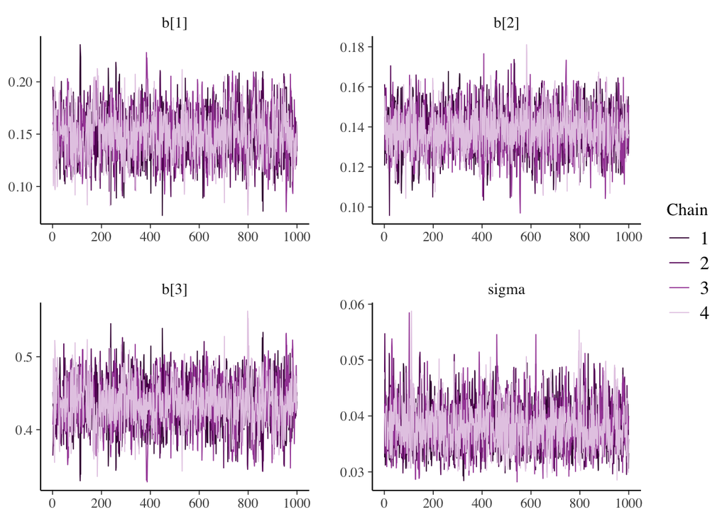

```r
mcmc_trace(fit.5.3$draws(), regex_pars = c('b', 'sigma'))
```

Check distributions.

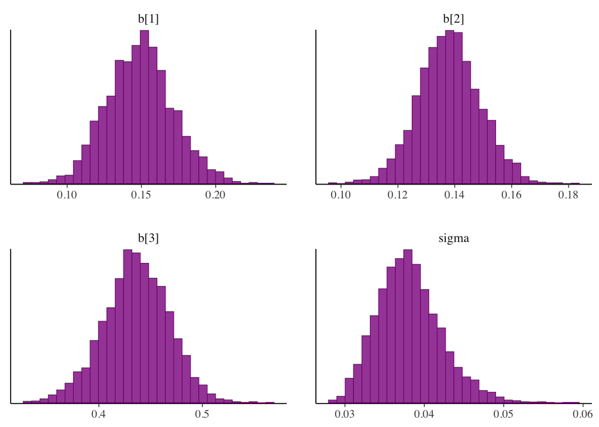

```r
mcmc_hist(fit.5.3$draws(), regex_pars = c('b', 'sigma'))
```

Posterior predictive checks are used to overlay posterior predictive distribution and data distribution.

Plot of observed values vs predicted.

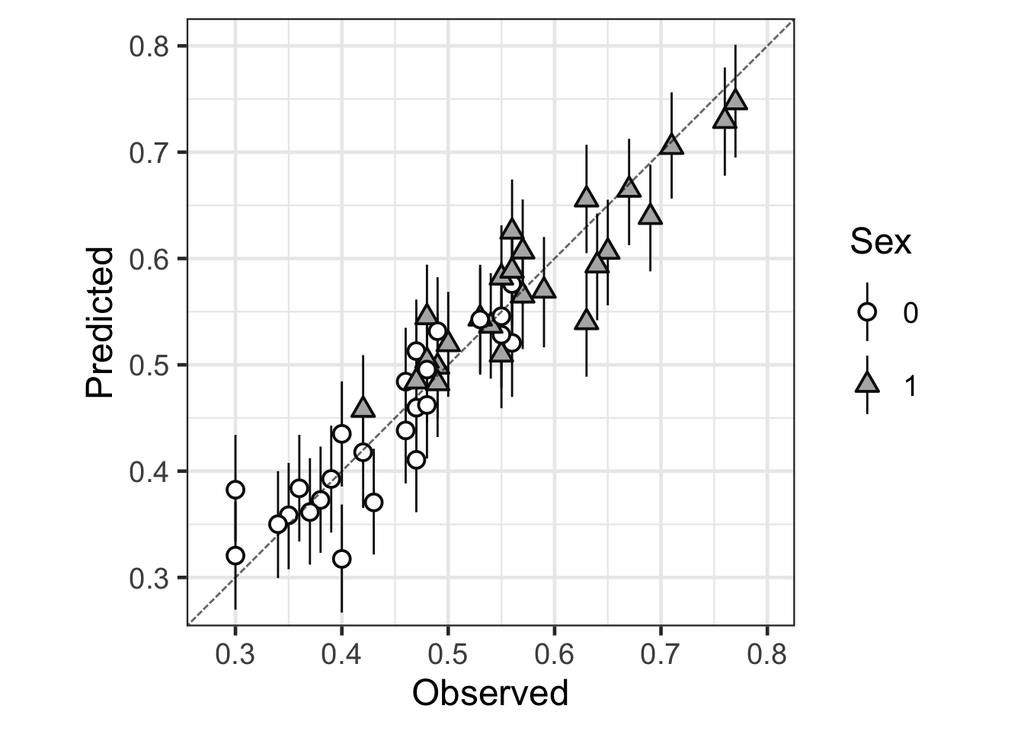

```r
# get posterior draws
# default is a 3-D draws_array object from the posterior package
# iterations x chains x variables
yp_ms <- fit.5.3$draws('yp', format = 'matrix') # or format="array"

# column-wise to get quantiles
qua <- apply(yp_ms, 2, quantile, prob=c(0.1, 0.5, 0.9))
d_est <- data.frame(d, t(qua), check.names=FALSE) |>
  mutate(Sex = as.factor(Sex))

# plot of quantiles
ggplot(
  data=d_est, aes(x=Y, y=`50%`, ymin=`10%`, ymax=`90%`, shape=Sex, fill=Sex)
  ) +
  theme_bw(base_size=18) +
  theme(legend.key.height=grid::unit(2.5,'line')) +
  coord_fixed(ratio=1, xlim=c(0.28, .8), ylim=c(0.28, .8)) +
  geom_pointrange(size=0.8, color='gray5') +
  geom_abline(aes(slope=1, intercept=0),
              color='black', alpha=3/5, linetype='31') +
  scale_shape_manual(values=c(21, 24)) +
  scale_fill_manual(values=c('white', 'gray70')) +
  labs(x='Observed', y='Predicted') +
  scale_x_continuous(breaks=seq(from=0, to=1, by=0.1)) +
  scale_y_continuous(breaks=seq(from=0, to=1, by=0.1))
```

Posterior residual checks (PRC)

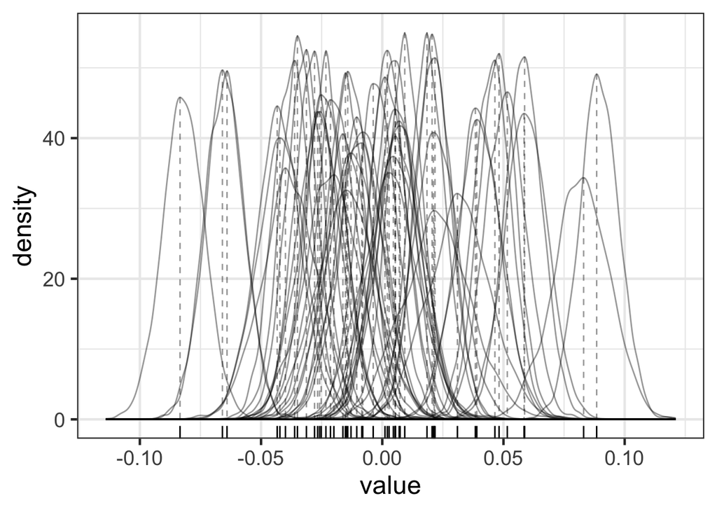

```r
mu_ms <- fit.5.3$draws('mu', format='matrix')
N_ms <- nrow(mu_ms)
noise_ms <- t(replicate(N_ms, data_5.1$Y)) - mu_ms
# noise_ms <- einsum::einsum('n,m->mn', d$Y, rep(1, N_ms)) - mu_ms

d_est <- data.frame(noise_ms, check.names=FALSE) |>
  tidyr::pivot_longer(cols=everything(), names_to='Parameter') |>
  mutate(PersonID = readr::parse_number(Parameter))

d_mode <- apply(noise_ms, 2, function(x) {
  dens <- density(x)
  mode_i <- which.max(dens$y)
  mode_x <- dens$x[mode_i]
  mode_y <- dens$y[mode_i]
  c(mode_x, mode_y)
}) |>
  t() |>
  data.frame() |>
  magrittr::set_colnames(c('X', 'Y'))

p <- ggplot() +
  theme_bw(base_size=18) +
  geom_line(data=d_est, aes(x=value, group=PersonID), stat='density', color='black', alpha=0.4) +
  geom_segment(data=d_mode, aes(x=X, xend=X, y=Y, yend=0), color='black', linetype='dashed', alpha=0.4) +
  geom_rug(data=d_mode, aes(x=X), sides='b') +
  labs(x='value', y='density')

p
```

In [Bayesian statistics](https://en.wikipedia.org/wiki/Bayesian_statistics), a **maximum a posteriori probability** (**MAP**) **estimate** is an estimate of an unknown quantity, that equals the mode of the [posterior distribution](https://en.wikipedia.org/wiki/Posterior_distribution). The MAP can be used to obtain a [point estimate](https://en.wikipedia.org/wiki/Point_estimation) of an unobserved quantity on the basis of empirical data. It is closely related to the method of [maximum likelihood](https://en.wikipedia.org/wiki/Maximum_likelihood) (ML) estimation, but employs an augmented optimization objective which incorporates a [prior distribution](https://en.wikipedia.org/wiki/Prior_distribution) (that quantifies the additional information available through prior knowledge of a related event) over the quantity one wants to estimate. MAP estimation can therefore be seen as a regularization of maximum likelihood estimation.

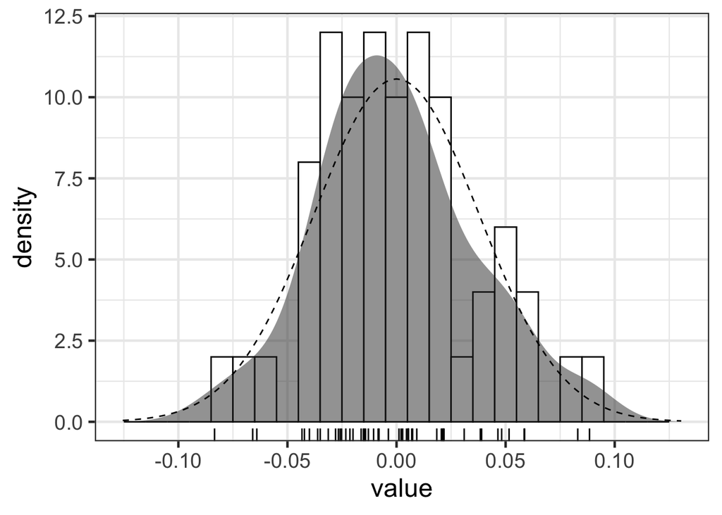

```r
s_dens <- density(fit.5.3$draws('sigma', format='matrix'))
s_MAP <- s_dens$x[which.max(s_dens$y)]
bw <- 0.01

p <- ggplot(data=d_mode, aes(x=X)) +
  theme_bw(base_size=18) +
  geom_histogram(
    aes(y=after_stat(density)), binwidth=bw, color='black', fill='white'
    ) +
  geom_density(color=NA, fill='gray20', alpha=0.5) +
  geom_rug(sides='b') +
  stat_function(fun=function(x) dnorm(x, mean=0, sd=s_MAP), linetype='dashed',
                color = 'black') +
  labs(x='value', y='density') +
  xlim(range(density(d_mode$X)$x))

p
```

### 5.3 Binomial Logistic Regression

Similar data but instead of the proportion already calculated as Y, we are given Y count of purchases and M visits to website. Income and sex are the same predictors.

```r
data_5.3 <-
  read.csv('./data/data-shopping-2.csv') |>
  mutate(Income = Income / 100) # scaled income like we did above

head(data_5.3)
```

```
  PersonID Sex Income  M Y
1        1   0  0.851  9 6
2        2   1  0.646 12 4
3        3   0  0.976  6 5
4        4   1  0.728  9 9
5        5   1  0.511 11 6
6        6   0  0.869  7 4
```

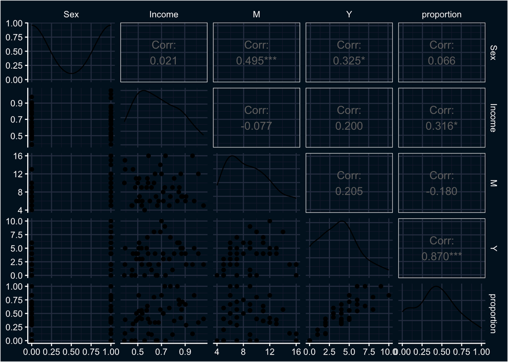

```r
data_5.3 |>
  mutate(proportion = Y / M) |>
  select(-PersonID) |>
  ggpairs() +
  night_owl_theme
```

*Formula 5.4*

Model formula for logistic model.

$$q[n] = logit^{-1}(b_1 + b_2Sex[n] + b_3Income[n]) \\
Y[n] \backsim binomial(M[n], q[n])$$
{#eq-5.4 - binomial logistic}

```r
# salary 2 data as a list
d2 <- as.list(data_5.3)
# number of rows
d2$N <- nrow(data_5.3)

# load model
model.5.4 = cmdstan_model(
  stan_file = './stan/model5-4.stan'
  )

# fit model to observed data
fit.5.4 = model.5.4$sample(data = d2, seed = 123, parallel_chains = 4)
```

```
Running MCMC with 4 parallel chains...

Chain 1 Iteration:    1 / 2000 [  0%]  (Warmup)
Chain 1 Iteration:  100 / 2000 [  5%]  (Warmup)
Chain 1 Iteration:  200 / 2000 [ 10%]  (Warmup)
Chain 1 Iteration:  300 / 2000 [ 15%]  (Warmup)
Chain 1 Iteration:  400 / 2000 [ 20%]  (Warmup)
Chain 1 Iteration:  500 / 2000 [ 25%]  (Warmup)
Chain 1 Iteration:  600 / 2000 [ 30%]  (Warmup)
Chain 1 Iteration:  700 / 2000 [ 35%]  (Warmup)
Chain 1 Iteration:  800 / 2000 [ 40%]  (Warmup)
Chain 1 Iteration:  900 / 2000 [ 45%]  (Warmup)
Chain 1 Iteration: 1000 / 2000 [ 50%]  (Warmup)
Chain 1 Iteration: 1001 / 2000 [ 50%]  (Sampling)
Chain 1 Iteration: 1100 / 2000 [ 55%]  (Sampling)
Chain 1 Iteration: 1200 / 2000 [ 60%]  (Sampling)
Chain 1 Iteration: 1300 / 2000 [ 65%]  (Sampling)
Chain 1 Iteration: 1400 / 2000 [ 70%]  (Sampling)
Chain 1 Iteration: 1500 / 2000 [ 75%]  (Sampling)
Chain 1 Iteration: 1600 / 2000 [ 80%]  (Sampling)
Chain 1 Iteration: 1700 / 2000 [ 85%]  (Sampling)
Chain 1 Iteration: 1800 / 2000 [ 90%]  (Sampling)
Chain 1 Iteration: 1900 / 2000 [ 95%]  (Sampling)
Chain 2 Iteration:    1 / 2000 [  0%]  (Warmup)
Chain 2 Iteration:  100 / 2000 [  5%]  (Warmup)
Chain 2 Iteration:  200 / 2000 [ 10%]  (Warmup)
Chain 2 Iteration:  300 / 2000 [ 15%]  (Warmup)
Chain 2 Iteration:  400 / 2000 [ 20%]  (Warmup)
Chain 2 Iteration:  500 / 2000 [ 25%]  (Warmup)
Chain 2 Iteration:  600 / 2000 [ 30%]  (Warmup)
Chain 2 Iteration:  700 / 2000 [ 35%]  (Warmup)
Chain 2 Iteration:  800 / 2000 [ 40%]  (Warmup)
Chain 2 Iteration:  900 / 2000 [ 45%]  (Warmup)
Chain 2 Iteration: 1000 / 2000 [ 50%]  (Warmup)
Chain 2 Iteration: 1001 / 2000 [ 50%]  (Sampling)
Chain 2 Iteration: 1100 / 2000 [ 55%]  (Sampling)
Chain 2 Iteration: 1200 / 2000 [ 60%]  (Sampling)
Chain 2 Iteration: 1300 / 2000 [ 65%]  (Sampling)
Chain 2 Iteration: 1400 / 2000 [ 70%]  (Sampling)
Chain 2 Iteration: 1500 / 2000 [ 75%]  (Sampling)
```

[output cut: 43 more lines]

```
Chain 4 Iteration: 1800 / 2000 [ 90%]  (Sampling)
Chain 4 Iteration: 1900 / 2000 [ 95%]  (Sampling)
Chain 1 Iteration: 2000 / 2000 [100%]  (Sampling)
Chain 1 finished in 0.1 seconds.
Chain 2 Iteration: 2000 / 2000 [100%]  (Sampling)
Chain 2 finished in 0.1 seconds.
Chain 3 Iteration: 1900 / 2000 [ 95%]  (Sampling)
Chain 3 Iteration: 2000 / 2000 [100%]  (Sampling)
Chain 3 finished in 0.1 seconds.
Chain 4 Iteration: 2000 / 2000 [100%]  (Sampling)
Chain 4 finished in 0.1 seconds.

All 4 chains finished successfully.
Mean chain execution time: 0.1 seconds.
Total execution time: 0.2 seconds.
```

```r
# model summary
fit.5.4$summary(variables = c('b'))
```

```
# A tibble: 3 × 10
  variable    mean  median    sd   mad     q5    q95  rhat ess_bulk ess_tail
  <chr>      <num>   <num> <num> <num>  <num>  <num> <num>    <num>    <num>
1 b[1]     -1.47   -1.46   0.397 0.408 -2.14  -0.841  1.00    1349.    1633.
2 b[2]      0.0951  0.0964 0.195 0.191 -0.226  0.414  1.00    1807.    1672.
3 b[3]      1.57    1.56   0.559 0.561  0.666  2.50   1.00    1295.    1626.
```

Posterior distributions of betas.

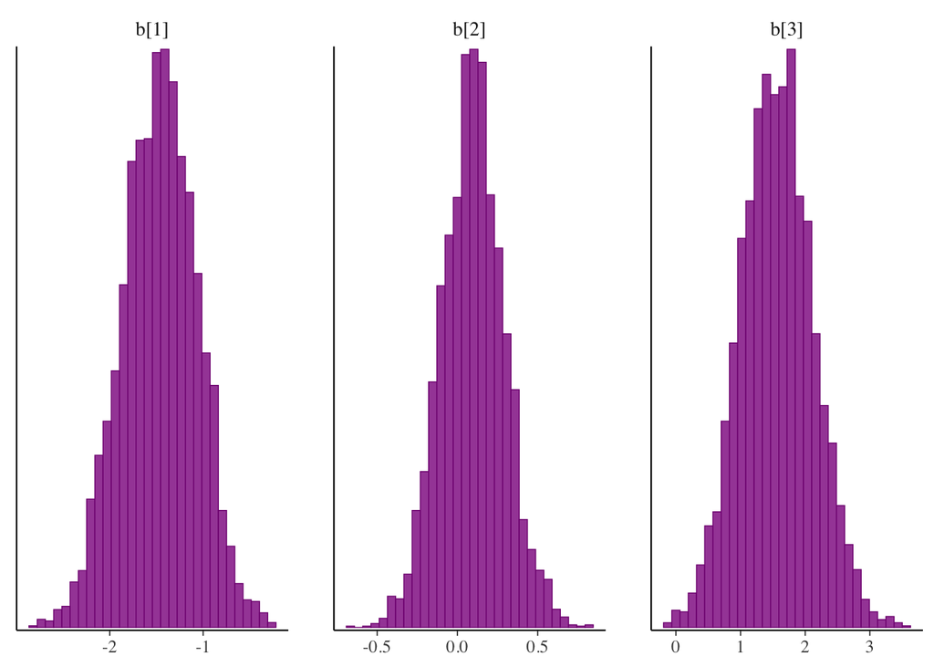

```r
mcmc_hist(fit.5.4$draws(), regex_pars = c('b'))
```

Extracting posterior draws to answer question of odds of purchasing for customer with income $90k vs $40k.

```r
draws.5.4 <- fit.5.4$draws(format = 'matrix')
# estimated means
exp(mean(draws.5.4[,4]*(90/100))) / exp(mean(draws.5.4[,4]*(40/100)))
```

```
[1] 2.18795
```

Skipping model checking etc.

### 5.4 Logistic Regression

Modification of the problem where instead of overall visits and counts of purchases per customer, we are interested in how discount influences a single purchase (binary 1 or 0).

```r
data_5.4 <- read.csv(
  "./data/data-shopping-3.csv"
  ) |>
  mutate(Income = Income / 100)
```

Checking distribution of discount by purchase.

```r
knitr::kable(
  prop.table(with( data_5.4, table(Discount, Y) ), 2 ) ,
  caption = 'Contigency table of discount by purchase (Y)'
  )
```

Contigency table of discount by purchase (Y)

|  | 0 | 1 |
| --- | --- | --- |
| 0 | 0.8854962 | 0.6153846 |
| 1 | 0.1145038 | 0.3846154 |

Bernoulli logistic model formula.

```r
# salary 2 data as a list
d3 <- as.list(data_5.4)
# number of rows
d3$V <- nrow(data_5.4)

# load model
model.5.5 = cmdstan_model(
  stan_file = './stan/model5-5.stan'
  )

# fit model to observed data
fit.5.5 = model.5.5$sample(data = d3, seed = 123, parallel_chains = 4)
```

```
Running MCMC with 4 parallel chains...

Chain 1 Iteration:    1 / 2000 [  0%]  (Warmup)
Chain 1 Iteration:  100 / 2000 [  5%]  (Warmup)
Chain 1 Iteration:  200 / 2000 [ 10%]  (Warmup)
Chain 2 Iteration:    1 / 2000 [  0%]  (Warmup)
Chain 2 Iteration:  100 / 2000 [  5%]  (Warmup)
Chain 2 Iteration:  200 / 2000 [ 10%]  (Warmup)
Chain 3 Iteration:    1 / 2000 [  0%]  (Warmup)
Chain 3 Iteration:  100 / 2000 [  5%]  (Warmup)
Chain 3 Iteration:  200 / 2000 [ 10%]  (Warmup)
Chain 4 Iteration:    1 / 2000 [  0%]  (Warmup)
Chain 4 Iteration:  100 / 2000 [  5%]  (Warmup)
Chain 4 Iteration:  200 / 2000 [ 10%]  (Warmup)
Chain 1 Iteration:  300 / 2000 [ 15%]  (Warmup)
Chain 1 Iteration:  400 / 2000 [ 20%]  (Warmup)
Chain 1 Iteration:  500 / 2000 [ 25%]  (Warmup)
Chain 2 Iteration:  300 / 2000 [ 15%]  (Warmup)
Chain 2 Iteration:  400 / 2000 [ 20%]  (Warmup)
Chain 2 Iteration:  500 / 2000 [ 25%]  (Warmup)
Chain 3 Iteration:  300 / 2000 [ 15%]  (Warmup)
Chain 3 Iteration:  400 / 2000 [ 20%]  (Warmup)
Chain 3 Iteration:  500 / 2000 [ 25%]  (Warmup)
Chain 4 Iteration:  300 / 2000 [ 15%]  (Warmup)
Chain 4 Iteration:  400 / 2000 [ 20%]  (Warmup)
Chain 4 Iteration:  500 / 2000 [ 25%]  (Warmup)
Chain 1 Iteration:  600 / 2000 [ 30%]  (Warmup)
Chain 1 Iteration:  700 / 2000 [ 35%]  (Warmup)
Chain 1 Iteration:  800 / 2000 [ 40%]  (Warmup)
Chain 2 Iteration:  600 / 2000 [ 30%]  (Warmup)
Chain 2 Iteration:  700 / 2000 [ 35%]  (Warmup)
Chain 2 Iteration:  800 / 2000 [ 40%]  (Warmup)
Chain 3 Iteration:  600 / 2000 [ 30%]  (Warmup)
Chain 3 Iteration:  700 / 2000 [ 35%]  (Warmup)
Chain 4 Iteration:  600 / 2000 [ 30%]  (Warmup)
Chain 4 Iteration:  700 / 2000 [ 35%]  (Warmup)
Chain 1 Iteration:  900 / 2000 [ 45%]  (Warmup)
Chain 1 Iteration: 1000 / 2000 [ 50%]  (Warmup)
Chain 1 Iteration: 1001 / 2000 [ 50%]  (Sampling)
Chain 2 Iteration:  900 / 2000 [ 45%]  (Warmup)
```

[output cut: 43 more lines]

```
Chain 3 Iteration: 1900 / 2000 [ 95%]  (Sampling)
Chain 4 Iteration: 1800 / 2000 [ 90%]  (Sampling)
Chain 4 Iteration: 1900 / 2000 [ 95%]  (Sampling)
Chain 1 finished in 1.0 seconds.
Chain 2 Iteration: 1900 / 2000 [ 95%]  (Sampling)
Chain 2 Iteration: 2000 / 2000 [100%]  (Sampling)
Chain 3 Iteration: 2000 / 2000 [100%]  (Sampling)
Chain 4 Iteration: 2000 / 2000 [100%]  (Sampling)
Chain 2 finished in 1.1 seconds.
Chain 3 finished in 1.0 seconds.
Chain 4 finished in 1.0 seconds.

All 4 chains finished successfully.
Mean chain execution time: 1.0 seconds.
Total execution time: 1.1 seconds.
```

Summary of model 5.5 (replacing b[i] with variable names).

```r
# model summary
summary_5.5 <- fit.5.5$summary(variables = c('b'))
summary_5.5$variable <- c('Intercept', 'Sex', 'Income', 'Discount')

summary_5.5
```

```
# A tibble: 4 × 10
  variable    mean median    sd   mad      q5    q95  rhat ess_bulk ess_tail
  <chr>      <num>  <num> <num> <num>   <num>  <num> <num>    <num>    <num>
1 Intercept -2.02  -2.02  0.425 0.433 -2.72   -1.34   1.00    1578.    1986.
2 Sex        0.268  0.266 0.221 0.222 -0.0850  0.634  1.00    2559.    2178.
3 Income     1.68   1.67  0.579 0.599  0.757   2.62   1.00    1659.    1929.
4 Discount   1.65   1.65  0.250 0.252  1.24    2.07   1.00    2683.    2292.
```

Note, how would you get the AUC? Something for another date.

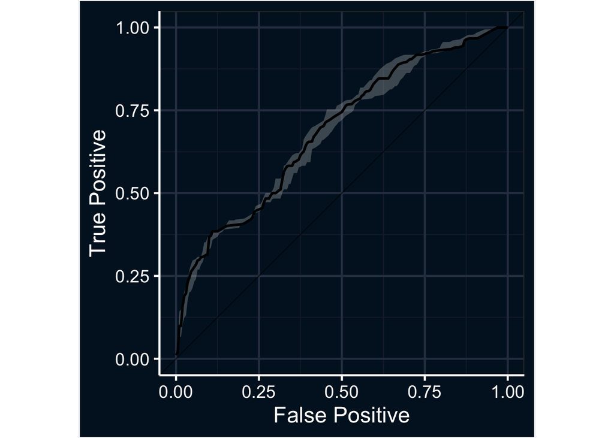

```r
q_ms <- fit.5.5$draws('q', format='matrix')
N_ms <- nrow(q_ms)
spec <- seq(from=0, to=1, len=201)
probs <- c(0.1, 0.5, 0.9)

auces <- numeric(N_ms)
m_roc <- matrix(nrow=N_ms, ncol=length(spec))

for (i in 1:N_ms) {
  roc_res <- roc(d3$Y, q_ms[i,], quiet=TRUE)
  auces[i] <- as.numeric(roc_res$auc)
  m_roc[i,] <- coords(roc_res, x=spec, input='specificity', ret='sensitivity') |> unlist()
}

# quantile(auces, prob=probs)
qua <- apply(m_roc, 2, quantile, prob=probs)
d_est <- data.frame(X=1-spec, t(qua), check.names=FALSE)

p <- ggplot(data=d_est, aes(x=X, y=`50%`)) +
  theme_bw(base_size=18) +
  theme(legend.position='none') +
  coord_fixed(ratio=1, xlim=c(0,1), ylim=c(0,1)) +
  geom_abline(intercept=0, slope=1, alpha=0.5) +
  geom_ribbon(aes(ymin=`10%`, ymax=`90%`), fill='grey', alpha=2/6) +
  geom_line(size=1) +
  labs(x='False Positive', y='True Positive') +
  night_owl_theme

p
```

Quick attempt at a calibration plot of the median predicted q (may not be right).

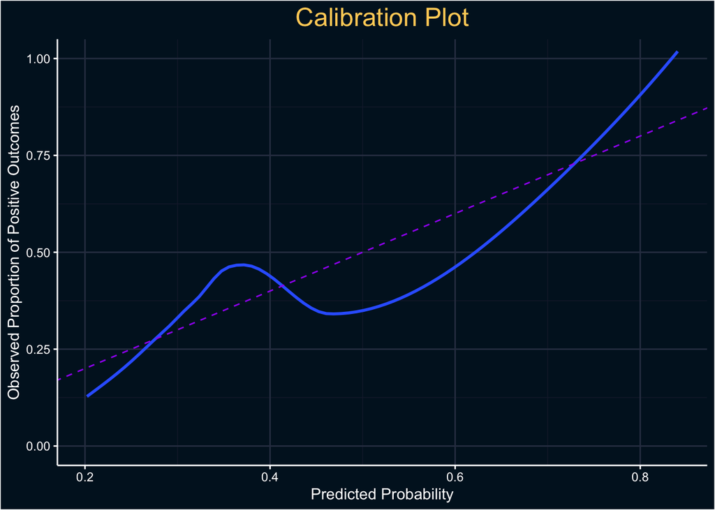

```r
qua_q <- apply(q_ms, 2, quantile, probs)

plot_data <- data.frame(d3, t(qua_q), check.names=FALSE)

ggplot() +
  geom_point() +
  geom_smooth(data = plot_data, aes(x=`50%`, y = Y), method = 'loess', se = FALSE) +
  geom_abline(intercept = 0, slope = 1, color = "purple", linetype = "dashed") +
  labs(x = "Predicted Probability", y = "Observed Proportion of Positive Outcomes",
       title = "Calibration Plot") +
  coord_cartesian(ylim = c(0,1)) +
  night_owl_theme
```

### 5.5 Poisson Regression

Poisson model formula 5.6:

Using data-shopping-2 file used above. List object is called d2.

```r
model.5.6 = cmdstan_model(
  stan_file = './stan/model5-6.stan'
  )

# fit model to observed data
fit.5.6 = model.5.6$sample(data = d2, seed = 123, parallel_chains = 4)
```

```
Running MCMC with 4 parallel chains...

Chain 1 Iteration:    1 / 2000 [  0%]  (Warmup)
Chain 1 Iteration:  100 / 2000 [  5%]  (Warmup)
Chain 1 Iteration:  200 / 2000 [ 10%]  (Warmup)
Chain 1 Iteration:  300 / 2000 [ 15%]  (Warmup)
Chain 1 Iteration:  400 / 2000 [ 20%]  (Warmup)
Chain 1 Iteration:  500 / 2000 [ 25%]  (Warmup)
Chain 1 Iteration:  600 / 2000 [ 30%]  (Warmup)
Chain 1 Iteration:  700 / 2000 [ 35%]  (Warmup)
Chain 1 Iteration:  800 / 2000 [ 40%]  (Warmup)
Chain 1 Iteration:  900 / 2000 [ 45%]  (Warmup)
Chain 1 Iteration: 1000 / 2000 [ 50%]  (Warmup)
Chain 1 Iteration: 1001 / 2000 [ 50%]  (Sampling)
Chain 1 Iteration: 1100 / 2000 [ 55%]  (Sampling)
Chain 1 Iteration: 1200 / 2000 [ 60%]  (Sampling)
Chain 1 Iteration: 1300 / 2000 [ 65%]  (Sampling)
Chain 1 Iteration: 1400 / 2000 [ 70%]  (Sampling)
Chain 1 Iteration: 1500 / 2000 [ 75%]  (Sampling)
Chain 1 Iteration: 1600 / 2000 [ 80%]  (Sampling)
Chain 1 Iteration: 1700 / 2000 [ 85%]  (Sampling)
Chain 1 Iteration: 1800 / 2000 [ 90%]  (Sampling)
Chain 1 Iteration: 1900 / 2000 [ 95%]  (Sampling)
Chain 1 Iteration: 2000 / 2000 [100%]  (Sampling)
Chain 2 Iteration:    1 / 2000 [  0%]  (Warmup)
Chain 2 Iteration:  100 / 2000 [  5%]  (Warmup)
Chain 2 Iteration:  200 / 2000 [ 10%]  (Warmup)
Chain 2 Iteration:  300 / 2000 [ 15%]  (Warmup)
Chain 2 Iteration:  400 / 2000 [ 20%]  (Warmup)
Chain 2 Iteration:  500 / 2000 [ 25%]  (Warmup)
Chain 2 Iteration:  600 / 2000 [ 30%]  (Warmup)
Chain 2 Iteration:  700 / 2000 [ 35%]  (Warmup)
Chain 2 Iteration:  800 / 2000 [ 40%]  (Warmup)
Chain 2 Iteration:  900 / 2000 [ 45%]  (Warmup)
Chain 2 Iteration: 1000 / 2000 [ 50%]  (Warmup)
Chain 2 Iteration: 1001 / 2000 [ 50%]  (Sampling)
Chain 2 Iteration: 1100 / 2000 [ 55%]  (Sampling)
Chain 2 Iteration: 1200 / 2000 [ 60%]  (Sampling)
Chain 2 Iteration: 1300 / 2000 [ 65%]  (Sampling)
Chain 2 Iteration: 1400 / 2000 [ 70%]  (Sampling)
```

[output cut: 43 more lines]

```
Chain 4 Iteration: 1400 / 2000 [ 70%]  (Sampling)
Chain 4 Iteration: 1500 / 2000 [ 75%]  (Sampling)
Chain 4 Iteration: 1600 / 2000 [ 80%]  (Sampling)
Chain 4 Iteration: 1700 / 2000 [ 85%]  (Sampling)
Chain 4 Iteration: 1800 / 2000 [ 90%]  (Sampling)
Chain 4 Iteration: 1900 / 2000 [ 95%]  (Sampling)
Chain 1 finished in 0.1 seconds.
Chain 2 finished in 0.1 seconds.
Chain 3 finished in 0.1 seconds.
Chain 4 Iteration: 2000 / 2000 [100%]  (Sampling)
Chain 4 finished in 0.1 seconds.

All 4 chains finished successfully.
Mean chain execution time: 0.1 seconds.
Total execution time: 0.2 seconds.
```

Summary of model 5.6.

```r
# model summary
summary_5.6 <- fit.5.6$summary(variables = c('b'))
summary_5.6$variable <- c('Intercept', 'Sex', 'Income')

summary_5.6
```

```
# A tibble: 3 × 10
  variable    mean median     sd    mad     q5   q95  rhat ess_bulk ess_tail
  <chr>      <num>  <num>  <num>  <num>  <num> <num> <num>    <num>    <num>
1 Intercept  2.11   2.11  0.198  0.194   1.79  2.44   1.00    1303.    1415.
2 Sex        0.363  0.361 0.0956 0.0940  0.208 0.518  1.00    1802.    1340.
3 Income    -0.198 -0.199 0.280  0.275  -0.663 0.268  1.00    1287.    1336.
```

Example in book estimating income of 90 vs income of 40.

```r
draws.5.6 <- fit.5.6$draws('b', format='matrix')

mean(exp(draws.5.6[,3] * ((90 - 40)/100)))
```

```
[1] 0.9145217
```

### 5.6 Expression Using Matrix Operation

Instead of specifying each parameter, we can use a predictor matrix instead.

```r
shopping_4 <-
  read.csv('./data/data-shopping-4.csv') |>
  mutate(Income = Income / 100)

head(shopping_4)
```

```
  PersonID Sex Income    X3   X4    Y
1        1   0  0.851 -0.56 1.20 0.56
2        2   1  0.646 -0.23 0.67 0.59
3        3   0  0.976  1.56 0.98 0.56
4        4   1  0.728  0.07 1.91 0.65
5        5   1  0.511  0.13 0.97 0.55
6        6   0  0.869  1.72 1.78 0.55
```

Model 5.7 using a matrix.

```r
# Predictor matrix X
X <- cbind(
  data.frame(Intercept = 1),
  shopping_4[, 2:(ncol(shopping_4)-1)]
  )

d4 <- list(
  N = nrow(shopping_4),
  Y = shopping_4$Y,
  X = X,
  D = ncol(X)
)

model.5.7 = cmdstan_model(
  stan_file = './stan/model5-7.stan'
  )

# fit model to observed data
fit.5.7 = model.5.7$sample(data = d4, seed = 123, parallel_chains = 4)
```

```
Running MCMC with 4 parallel chains...

Chain 1 Iteration:    1 / 2000 [  0%]  (Warmup)
Chain 1 Iteration:  100 / 2000 [  5%]  (Warmup)
Chain 1 Iteration:  200 / 2000 [ 10%]  (Warmup)
Chain 1 Iteration:  300 / 2000 [ 15%]  (Warmup)
Chain 1 Iteration:  400 / 2000 [ 20%]  (Warmup)
Chain 1 Iteration:  500 / 2000 [ 25%]  (Warmup)
Chain 1 Iteration:  600 / 2000 [ 30%]  (Warmup)
Chain 1 Iteration:  700 / 2000 [ 35%]  (Warmup)
Chain 1 Iteration:  800 / 2000 [ 40%]  (Warmup)
Chain 1 Iteration:  900 / 2000 [ 45%]  (Warmup)
Chain 1 Iteration: 1000 / 2000 [ 50%]  (Warmup)
Chain 1 Iteration: 1001 / 2000 [ 50%]  (Sampling)
Chain 1 Iteration: 1100 / 2000 [ 55%]  (Sampling)
Chain 1 Iteration: 1200 / 2000 [ 60%]  (Sampling)
Chain 1 Iteration: 1300 / 2000 [ 65%]  (Sampling)
Chain 1 Iteration: 1400 / 2000 [ 70%]  (Sampling)
Chain 1 Iteration: 1500 / 2000 [ 75%]  (Sampling)
Chain 1 Iteration: 1600 / 2000 [ 80%]  (Sampling)
Chain 1 Iteration: 1700 / 2000 [ 85%]  (Sampling)
Chain 1 Iteration: 1800 / 2000 [ 90%]  (Sampling)
Chain 1 Iteration: 1900 / 2000 [ 95%]  (Sampling)
Chain 1 Iteration: 2000 / 2000 [100%]  (Sampling)
Chain 2 Iteration:    1 / 2000 [  0%]  (Warmup)
Chain 2 Iteration:  100 / 2000 [  5%]  (Warmup)
Chain 2 Iteration:  200 / 2000 [ 10%]  (Warmup)
Chain 2 Iteration:  300 / 2000 [ 15%]  (Warmup)
Chain 2 Iteration:  400 / 2000 [ 20%]  (Warmup)
Chain 2 Iteration:  500 / 2000 [ 25%]  (Warmup)
Chain 2 Iteration:  600 / 2000 [ 30%]  (Warmup)
Chain 2 Iteration:  700 / 2000 [ 35%]  (Warmup)
Chain 2 Iteration:  800 / 2000 [ 40%]  (Warmup)
Chain 2 Iteration:  900 / 2000 [ 45%]  (Warmup)
Chain 2 Iteration: 1000 / 2000 [ 50%]  (Warmup)
Chain 2 Iteration: 1001 / 2000 [ 50%]  (Sampling)
Chain 2 Iteration: 1100 / 2000 [ 55%]  (Sampling)
Chain 2 Iteration: 1200 / 2000 [ 60%]  (Sampling)
Chain 2 Iteration: 1300 / 2000 [ 65%]  (Sampling)
Chain 2 Iteration: 1400 / 2000 [ 70%]  (Sampling)
```

[output cut: 43 more lines]

```
Chain 4 Iteration: 1400 / 2000 [ 70%]  (Sampling)
Chain 4 Iteration: 1500 / 2000 [ 75%]  (Sampling)
Chain 4 Iteration: 1600 / 2000 [ 80%]  (Sampling)
Chain 4 Iteration: 1700 / 2000 [ 85%]  (Sampling)
Chain 4 Iteration: 1800 / 2000 [ 90%]  (Sampling)
Chain 4 Iteration: 1900 / 2000 [ 95%]  (Sampling)
Chain 4 Iteration: 2000 / 2000 [100%]  (Sampling)
Chain 1 finished in 0.1 seconds.
Chain 2 finished in 0.1 seconds.
Chain 3 finished in 0.1 seconds.
Chain 4 finished in 0.1 seconds.

All 4 chains finished successfully.
Mean chain execution time: 0.1 seconds.
Total execution time: 0.2 seconds.
```

Model summary of 5.7.

```r
# model summary
summary_5.7 <- fit.5.7$summary(variables = c('b'))
summary_5.7$variable <- names(X)

summary_5.7
```

```
# A tibble: 5 × 10
  variable       mean    median      sd     mad       q5     q95  rhat ess_bulk
  <chr>         <num>     <num>   <num>   <num>    <num>   <num> <num>    <num>
1 Intercept  0.131     0.131    0.0235  0.0232   0.0934  0.170    1.00    2291.
2 Sex        0.136     0.135    0.0109  0.0109   0.118   0.153    1.00    3104.
3 Income     0.440     0.440    0.0304  0.0302   0.390   0.491    1.00    2420.
4 X3        -0.000710 -0.000689 0.00572 0.00567 -0.0100  0.00856  1.00    4643.
5 X4         0.0159    0.0161   0.00907 0.00903  0.00107 0.0308   1.00    3267.
# ℹ 1 more variable: ess_tail <num>
```

### 5.7.1 Exercises

1. Use MCMC samples from model5.3 to compute the MCMC sample of $\epsilon[n] = Y[n] - \mu[n]$ for each n (i.e. residuals).

```r
# get the draws for 5.3
draws5.3 <- fit.5.3$draws('yp', format = 'matrix')
```